# Logistic Regression

Luca Baggi

# Load packages

```r
library(tidymodels)
library(AER)
```

Also, set seed!

# Load data

```r
summary(SwissLabor)
```

```
 participation     income            age          education        youngkids
 no :471       Min.   : 7.187   Min.   :2.000   Min.   : 1.000   Min.   :0.0000
 yes:401       1st Qu.:10.472   1st Qu.:3.200   1st Qu.: 8.000   1st Qu.:0.0000
               Median :10.643   Median :3.900   Median : 9.000   Median :0.0000
               Mean   :10.686   Mean   :3.996   Mean   : 9.307   Mean   :0.3119
               3rd Qu.:10.887   3rd Qu.:4.800   3rd Qu.:12.000   3rd Qu.:0.0000
               Max.   :12.376   Max.   :6.200   Max.   :21.000   Max.   :3.0000
    oldkids       foreign
 Min.   :0.0000   no :656
 1st Qu.:0.0000   yes:216
 Median :1.0000
 Mean   :0.9828
 3rd Qu.:2.0000
 Max.   :6.0000
```

See the levels:

```r
levels(SwissLabor$participation)
```

```
[1] "no"  "yes"
```

# Partition the data

```r
train_set <- juice(labour_recipe)

test_set <- labour_recipe %>%
  bake(testing(labour_split))
```

# Model Fitting

## Linear Regression

This won’t work!

```r
linear_model <- lm(participation ~ ., data = SwissLabor) %>%
  summary()
```

```
using type = "numeric" with a factor response will be ignored‘-’ not meaningful for factors‘^’ not meaningful for factors
```

And so won’t any other `lm` or `glm` model, as the response variable is not numeric.

```r
linear_regression <- linear_reg(mode = 'regression') %>%
  set_engine('lm') %>%
  fit(participation ~ ., data = train_set)
```

```
Error: For a regression model, the outcome should be numeric.
Run `rlang::last_error()` to see where the error occurred.
```

## Logistic regression

### Using GLM

From the [documentation](https://www.rdocumentation.org/packages/stats/versions/3.6.2/topics/family) of the `glm` command:

> the binomial family the links logit, probit, cauchit, (corresponding to logistic, normal and Cauchy CDFs respectively) log and cloglog (complementary log-log);

### Using `tidymodels` & `parsnip`

There is no need to specify the mode, as the default for `logistic_reg()` is `mode = 'classification'`. See the [docs](https://parsnip.tidymodels.org/reference/logistic_reg.html)

One could also write the following when a `mode` is to be specified.

```
logistic_regression <- logistic_reg() %>%
  set_engine('glm') %>%
  set_mode('classifier') %>%
  fit(...)
```

# Predictions

Let’s predict the classes of `test_set`:

```r
logistic_regression %>%
  predict(test_set) %>%
  bind_cols(test_set) %>%
  glimpse()
```

[output not shown]

# Model Validation

## General metrics

| .metric | .estimator | .estimate |
| --- | --- | --- |
| accuracy | binary | 0.6422018 |
| kap | binary | 0.2674479 |

The accuracy is pretty low!

### Confusion Matrix

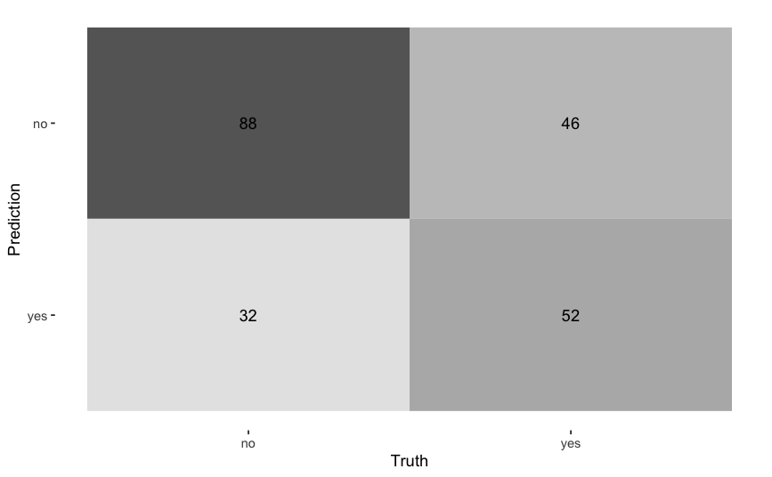

## Per-classifier metrics

Let’s predict the probabilities for each class and assign the resulting data to a new variable:

```r
predicted_probs <- logistic_regression %>%
  predict(test_set, type = 'prob') %>%
  bind_cols(test_set) %>%
  glimpse()
```

```
Rows: 218
Columns: 9
$ .pred_no      <dbl> 0.5905765, 0.9334372, 0.6693538, 0.6892431, 0.6963352, 0.5263953, 0…
$ .pred_yes     <dbl> 0.4094235, 0.0665628, 0.3306462, 0.3107569, 0.3036648, 0.4736047, 0…
$ income        <dbl> 10.660618, 11.229592, 10.861253, 11.048627, 10.957795, 10.482397, 1…
$ age           <dbl> 4.5, 3.3, 5.0, 4.7, 5.3, 2.0, 4.7, 2.8, 5.5, 2.3, 5.3, 4.5, 2.2, 3.…
$ education     <dbl> 11, 11, 8, 8, 11, 12, 8, 9, 8, 10, 12, 12, 10, 9, 12, 10, 13, 10, 9…
$ youngkids     <dbl> 0, 2, 0, 0, 0, 1, 0, 2, 0, 0, 0, 0, 1, 0, 0, 0, 0, 1, 1, 0, 0, 0, 0…
$ oldkids       <dbl> 2, 0, 0, 1, 0, 0, 0, 0, 0, 1, 0, 1, 0, 2, 0, 2, 2, 1, 0, 0, 2, 3, 1…
$ foreign       <fct> no, no, no, no, no, no, no, no, no, no, no, no, no, no, no, no, no,…
$ participation <fct> no, no, no, no, yes, no, yes, no, no, no, no, no, no, yes, yes, no,…
```

And then compute the ROC curve:

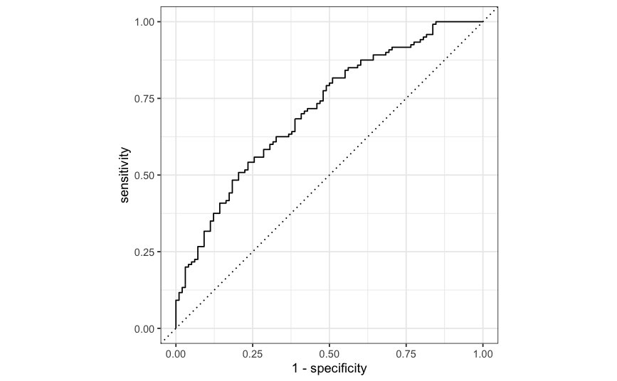

Note: there is no need to specify the full range `.pred_no:.pred_yes` as the metric is binary. Indeed, `yardstick`, the package doing all of the metrics within `tidyverse`, signals error if you attempt to do so.

Not much to say: the model is pretty bad with only these features! What could be done to improve it? Perhaps adding a time dimension?